# NLP_Project_Full_Code_completed

## **Problem Statement**

### Business Context

The prices of the stocks of companies listed under a global exchange are influenced by a variety of factors, with the company's financial performance, innovations and collaborations, and market sentiment being factors that play a significant role. News and media reports can rapidly affect investor perceptions and, consequently, stock prices in the highly competitive financial industry. With the sheer volume of news and opinions from a wide variety of sources, investors and financial analysts often struggle to stay updated and accurately interpret its impact on the market. As a result, investment firms need sophisticated tools to analyze market sentiment and integrate this information into their investment strategies.

### Problem Definition

With an ever-rising number of news articles and opinions, an investment startup aims to leverage artificial intelligence to address the challenge of interpreting stock-related news and its impact on stock prices. They have collected historical daily news for a specific company listed under NASDAQ, along with data on its daily stock price and trade volumes.

As a member of the Data Science and AI team in the startup, you have been tasked with analyzing the data, developing an AI-driven sentiment analysis system that will automatically process and analyze news articles to gauge market sentiment, and summarizing the news at a weekly level to enhance the accuracy of their stock price predictions and optimize investment strategies. This will empower their financial analysts with actionable insights, leading to more informed investment decisions and improved client outcomes.

### Data Dictionary

- `Date` : The date the news was released
- `News` : The content of news articles that could potentially affect the company's stock price
- `Open` : The stock price (in $) at the beginning of the day
- `High` : The highest stock price (in $) reached during the day
- `Low` : The lowest stock price (in $) reached during the day
- `Close` : The adjusted stock price (in $) at the end of the day
- `Volume` : The number of shares traded during the day
- `Label` : The sentiment polarity of the news content
  - 1: positive
  - 0: neutral
  - -1: negative

## **Installing and Importing Necessary Libraries**

```python
# installing the sentence-transformers and gensim libraries for word embeddings
!pip install sentencepiece hf_hub_download
```

```python
import pandas as pd
import numpy as np
pd.set_option('max_colwidth', None)    # setting column to the maximum column width as per the data
np.set_printoptions(suppress=True)

# to visualise data
import matplotlib.pyplot as plt
import seaborn as sns

# Deep Learning library
import torch

# to load transformer models
from sentence_transformers import SentenceTransformer
from transformers import T5Tokenizer, T5ForConditionalGeneration, pipeline
# To import Word2Vec
from gensim.models import Word2Vec

# to load the natural language toolkit
import nltk
nltk.download('stopwords')    # loading the stopwords
# nltk.download('punkt')    # loading the punkt module used in tokenization
# nltk.download('omw-1.4')    # dependency for tokenization
nltk.download('wordnet')    # loading the wordnet module that is used in stemming

# to remove common stop words
from nltk.corpus import stopwords

# to visualize text data using wordcloud
# from wordcloud import STOPWORDS

# to perform stemming
from nltk.stem.porter import PorterStemmer


# to split the data
from sklearn.model_selection import train_test_split
from sklearn import preprocessing

# to compute performance metrics
from sklearn.metrics import confusion_matrix, classification_report, accuracy_score

# To build a Random Forest model
from sklearn.ensemble import RandomForestClassifier

import tensorflow as tf
from tensorflow import keras
from tensorflow.keras.models import Sequential
from tensorflow.keras.layers import Dense, Dropout

# to ignore unnecessary warnings
import warnings
warnings.filterwarnings("ignore")
```

## **Loading the dataset**

```python
''' from google.colab import drive
drive.mount('/content/drive')'''
```

```
" from google.colab import drive\ndrive.mount('/content/drive')"
```

```python
file_csv = r"C:\entryplus\ep-projects\NLP-SentimentAnalysis\stock_news.csv"
df = pd.read_csv(file_csv)
df.head()
```

|  | Date | News | Open | High | Low | Close | Volume | Label |
| --- | --- | --- | --- | --- | --- | --- | --- | --- |
| 0 | 1/2/2019 | The tech sector experienced a significant decline in the aftermarket following Apple's Q1 revenue warning. Notable suppliers, including Skyworks, Broadcom, Lumentum, Qorvo, and TSMC, saw their stocks … | 41.740002 | 42.244999 | 41.482498 | 40.246914 | 130672400 | -1 |
| 1 | 1/2/2019 | Apple lowered its fiscal Q1 revenue guidance to $84 billion from earlier estimates of $89-$93 billion due to weaker than expected iPhone sales. The announcement caused a significant drop in Apple's st… | 41.740002 | 42.244999 | 41.482498 | 40.246914 | 130672400 | -1 |
| 2 | 1/2/2019 | Apple cut its fiscal first quarter revenue forecast from $89-$93 billion to $84 billion due to weaker demand in China and fewer iPhone upgrades. CEO Tim Cook also mentioned constrained sales of Airpod… | 41.740002 | 42.244999 | 41.482498 | 40.246914 | 130672400 | -1 |
| 3 | 1/2/2019 | This news article reports that yields on long-dated U.S. Treasury securities hit their lowest levels in nearly a year on January 2, 2019, due to concerns about the health of the global economy followi… | 41.740002 | 42.244999 | 41.482498 | 40.246914 | 130672400 | -1 |
| 4 | 1/2/2019 | Apple's revenue warning led to a decline in USD JPY pair and a gain in Japanese yen, as investors sought safety in the highly liquid currency. Apple's underperformance in Q1, with forecasted revenue o… | 41.740002 | 42.244999 | 41.482498 | 40.246914 | 130672400 | -1 |

## **Data Overview**

```python
df.shape
```

```
(349, 8)
```

```python
df.head()
```

|  | Date | News | Open | High | Low | Close | Volume | Label |
| --- | --- | --- | --- | --- | --- | --- | --- | --- |
| 0 | 1/2/2019 | The tech sector experienced a significant decline in the aftermarket following Apple's Q1 revenue warning. Notable suppliers, including Skyworks, Broadcom, Lumentum, Qorvo, and TSMC, saw their stocks … | 41.740002 | 42.244999 | 41.482498 | 40.246914 | 130672400 | -1 |
| 1 | 1/2/2019 | Apple lowered its fiscal Q1 revenue guidance to $84 billion from earlier estimates of $89-$93 billion due to weaker than expected iPhone sales. The announcement caused a significant drop in Apple's st… | 41.740002 | 42.244999 | 41.482498 | 40.246914 | 130672400 | -1 |
| 2 | 1/2/2019 | Apple cut its fiscal first quarter revenue forecast from $89-$93 billion to $84 billion due to weaker demand in China and fewer iPhone upgrades. CEO Tim Cook also mentioned constrained sales of Airpod… | 41.740002 | 42.244999 | 41.482498 | 40.246914 | 130672400 | -1 |
| 3 | 1/2/2019 | This news article reports that yields on long-dated U.S. Treasury securities hit their lowest levels in nearly a year on January 2, 2019, due to concerns about the health of the global economy followi… | 41.740002 | 42.244999 | 41.482498 | 40.246914 | 130672400 | -1 |
| 4 | 1/2/2019 | Apple's revenue warning led to a decline in USD JPY pair and a gain in Japanese yen, as investors sought safety in the highly liquid currency. Apple's underperformance in Q1, with forecasted revenue o… | 41.740002 | 42.244999 | 41.482498 | 40.246914 | 130672400 | -1 |

### Checking nulls

```python
df.isnull().sum()
```

```
Date      0
News      0
Open      0
High      0
Low       0
Close     0
Volume    0
Label     0
dtype: int64
```

### Checking Duplicates

```python
df.duplicated().sum()
```

```
0
```

### Checking Duplicates for columns date, open close, high, low, volume

```python
df.duplicated(subset=['Date', 'Open', 'Close', 'High', 'Low', 'Volume']).sum()
```

```
278
```

### Checking unique values

```python
df.nunique().sort_values(ascending=False)
```

```
News      349
Date       71
Low        71
Close      71
Volume     71
Open       70
High       70
Label       3
dtype: int64
```

### Checking value counts for label

```python
df['Label'].value_counts()
```

```
Label
 0    170
-1     99
 1     80
Name: count, dtype: int64
```

### Checking the summary statistics

```python
df.describe().T
```

|  | count | mean | std | min | 25% | 50% | 75% | max |
| --- | --- | --- | --- | --- | --- | --- | --- | --- |
| Open | 349.0 | 4.622923e+01 | 6.442817e+00 | 3.756750e+01 | 4.174000e+01 | 4.597500e+01 | 5.070750e+01 | 6.681750e+01 |
| High | 349.0 | 4.670046e+01 | 6.507321e+00 | 3.781750e+01 | 4.224500e+01 | 4.602500e+01 | 5.085000e+01 | 6.706250e+01 |
| Low | 349.0 | 4.574539e+01 | 6.391976e+00 | 3.730500e+01 | 4.148250e+01 | 4.564000e+01 | 4.977750e+01 | 6.586250e+01 |
| Close | 349.0 | 4.492632e+01 | 6.398338e+00 | 3.625413e+01 | 4.024691e+01 | 4.459692e+01 | 4.911079e+01 | 6.480523e+01 |
| Volume | 349.0 | 1.289482e+08 | 4.317031e+07 | 4.544800e+07 | 1.032720e+08 | 1.156272e+08 | 1.511252e+08 | 2.444392e+08 |
| Label | 349.0 | -5.444126e-02 | 7.151192e-01 | -1.000000e+00 | -1.000000e+00 | 0.000000e+00 | 0.000000e+00 | 1.000000e+00 |

### Checking the summary statistics for date column

```python
df['Date'] = pd.to_datetime(df['Date'])
```

```python
df['Date'].describe()
```

```
count                              349
mean     2019-02-16 16:05:30.085959936
min                2019-01-02 00:00:00
25%                2019-01-14 00:00:00
50%                2019-02-05 00:00:00
75%                2019-03-22 00:00:00
max                2019-04-30 00:00:00
Name: Date, dtype: object
```

```python
df['Date'].value_counts()
```

```
Date
2019-01-03    28
2019-01-30    17
2019-01-02    14
2019-04-17    12
2019-03-25    11
              ..
2019-02-19     1
2019-04-25     1
2019-04-26     1
2019-02-07     1
2019-04-16     1
Name: count, Length: 71, dtype: int64
```

```python
df['Date'].min()
```

```
Timestamp('2019-01-02 00:00:00')
```

```python
df['Date'].max()
```

```
Timestamp('2019-04-30 00:00:00')
```

```python
timeseries_df = df.groupby(['Date', 'Label'])['Volume'].count().reset_index(name='Count')
timeseries_df
```

|  | Date | Label | Count |
| --- | --- | --- | --- |
| 0 | 2019-01-02 | -1 | 10 |
| 1 | 2019-01-02 | 0 | 3 |
| 2 | 2019-01-02 | 1 | 1 |
| 3 | 2019-01-03 | -1 | 14 |
| 4 | 2019-01-03 | 0 | 10 |
| ... | ... | ... | ... |
| 152 | 2019-04-26 | 0 | 1 |
| 153 | 2019-04-29 | 0 | 1 |
| 154 | 2019-04-29 | 1 | 2 |
| 155 | 2019-04-30 | -1 | 4 |
| 156 | 2019-04-30 | 0 | 5 |

157 rows × 3 columns

## **Exploratory Data Analysis**

### Univariate Analysis

- Distribution of individual variables
- Compute and check the distribution of the length of news content

```python
numerical_columns = ['Open', 'Close', 'High', 'Low', 'Volume']
categorical_columns = ['Label']
```

```python
# Function to create labeled barplots


def labeled_barplot(data, feature, perc=False, n=None):
    """
    Barplot with percentage at the top

    data: dataframe
    feature: dataframe column
    perc: whether to display percentages instead of count (default is False)
    n: displays the top n category levels (default is None, i.e., display all levels)
    """

    total = len(data[feature])  # length of the column
    count = data[feature].nunique()
    if n is None:
        plt.figure(figsize=(count + 1, 5))
    else:
        plt.figure(figsize=(n + 1, 5))

    plt.xticks(rotation=90, fontsize=15)
    ax = sns.countplot(
        data=data,
        x=feature,
        palette="Paired",
        order=data[feature].value_counts().index[:n].sort_values(),
    )

    for p in ax.patches:
        if perc == True:
            label = "{:.1f}%".format(
                100 * p.get_height() / total
            )  # percentage of each class of the category
        else:
            label = p.get_height()  # count of each level of the category

        x = p.get_x() + p.get_width() / 2  # width of the plot
        y = p.get_height()  # height of the plot

        ax.annotate(
            label,
            (x, y),
            ha="center",
            va="center",
            size=12,
            xytext=(0, 5),
            textcoords="offset points",
        )  # annotate the percentage

    plt.show()  # show the plot
```

```python
# Function to plot a boxplot and a histogram along the same scale.


def histogram_boxplot(data, feature, figsize=(10, 7), kde=False, bins=None):
    """
    Boxplot and histogram combined

    data: dataframe
    feature: dataframe column
    figsize: size of figure (default (12,7))
    kde: whether to the show density curve (default False)
    bins: number of bins for histogram (default None)
    """
    f2, (ax_box2, ax_hist2) = plt.subplots(
        nrows=2,  # Number of rows of the subplot grid= 2
        sharex=True,  # x-axis will be shared among all subplots
        gridspec_kw={"height_ratios": (0.25, 0.75)},
        figsize=figsize,
    )  # creating the 2 subplots
    plt.title(feature + " Distribution")
    sns.boxplot(
        data=data, x=feature, ax=ax_box2, showmeans=True, color="violet"
    )  # boxplot will be created and a star will indicate the mean value of the column
    sns.histplot(
        data=data, x=feature, kde=kde, ax=ax_hist2, bins=bins, palette="winter"
    ) if bins else sns.histplot(
        data=data, x=feature, kde=kde, ax=ax_hist2
    )  # For histogram
    ax_hist2.axvline(
        data[feature].mean(), color="green", linestyle="--"
    )  # Add mean to the histogram
    ax_hist2.axvline(
        data[feature].median(), color="black", linestyle="-"
    )  # Add median to the histogram
```

```python
### Function to plot distributions


def distribution_plot_wrt_target(data, predictor, target):

    fig, axs = plt.subplots(2, 2, figsize=(10, 7))

    target_uniq = data[target].unique()

    axs[0, 0].set_title("Distribution of target for target=" + str(target_uniq[0]))
    sns.histplot(
        data=data[data[target] == target_uniq[0]],
        x=predictor,
        kde=True,
        ax=axs[0, 0],
        color="teal",
    )

    axs[0, 1].set_title("Distribution of target for target=" + str(target_uniq[1]))
    sns.histplot(
        data=data[data[target] == target_uniq[1]],
        x=predictor,
        kde=True,
        ax=axs[0, 1],
        color="orange",
    )

    axs[1, 0].set_title("Boxplot w.r.t target")
    sns.boxplot(data=data, x=target, y=predictor, ax=axs[1, 0], palette="gist_rainbow")

    axs[1, 1].set_title("Boxplot (without outliers) w.r.t target")
    sns.boxplot(
        data=data,
        x=target,
        y=predictor,
        ax=axs[1, 1],
        showfliers=False,
        palette="gist_rainbow",
    )

    plt.tight_layout()
    plt.show()
```

```python
# function to plot stacked bar chart


def stacked_barplot(data, predictor, target):
    """
    Print the category counts and plot a stacked bar chart

    data: dataframe
    predictor: independent variable
    target: target variable
    """
    count = data[predictor].nunique()
    sorter = data[target].value_counts().index[-1]
    tab1 = pd.crosstab(data[predictor], data[target], margins=True).sort_values(
        by=sorter, ascending=False
    )
    print(tab1)
    print("-" * 120)
    tab = pd.crosstab(data[predictor], data[target], normalize="index").sort_values(
        by=sorter, ascending=False
    )
    tab.plot(kind="bar", stacked=True, figsize=(count + 1, 5))
    plt.legend(
        loc="lower left",
        frameon=False,
    )
    plt.legend(loc="upper left", bbox_to_anchor=(1, 1))
    plt.show()
```

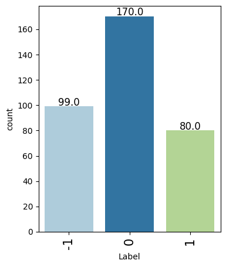

```python
for col in categorical_columns:
  labeled_barplot(df, col)
```

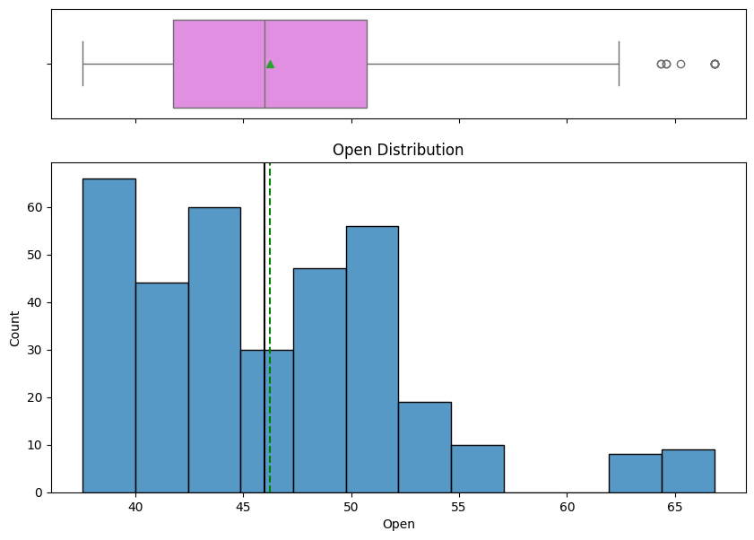

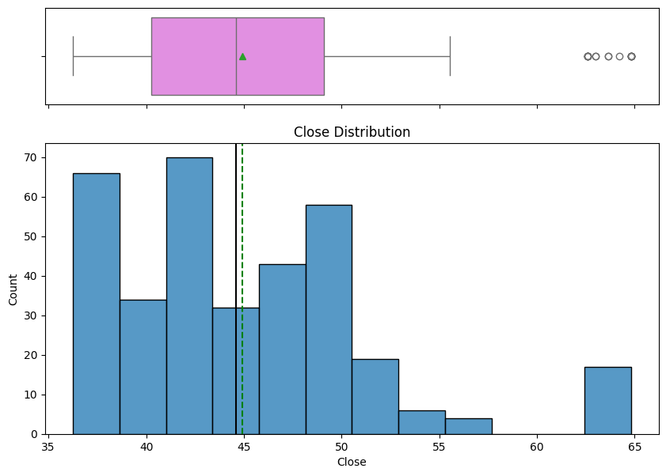

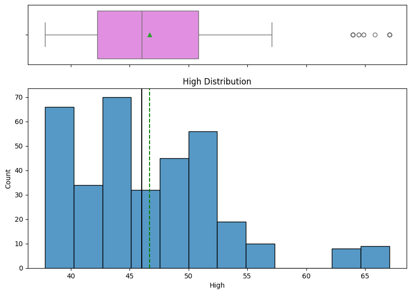

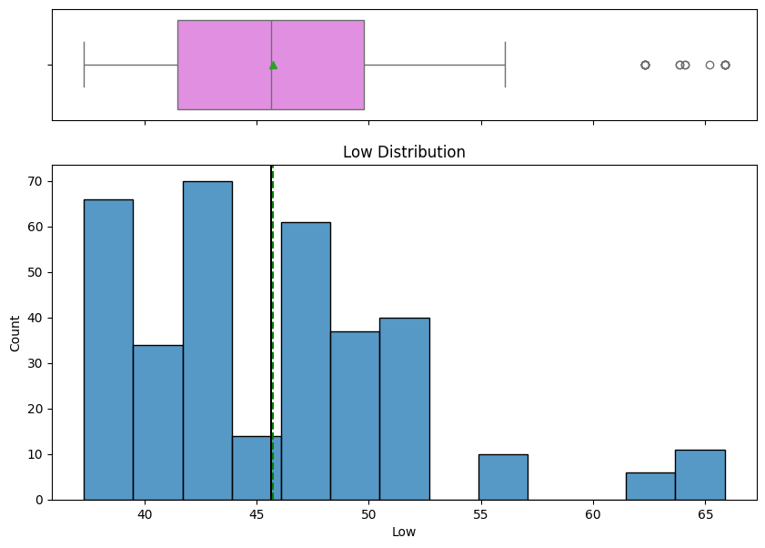

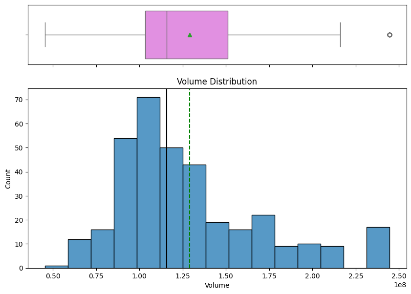

```python
for col in numerical_columns:
  histogram_boxplot(df, col)
```

### Bivariate Analysis

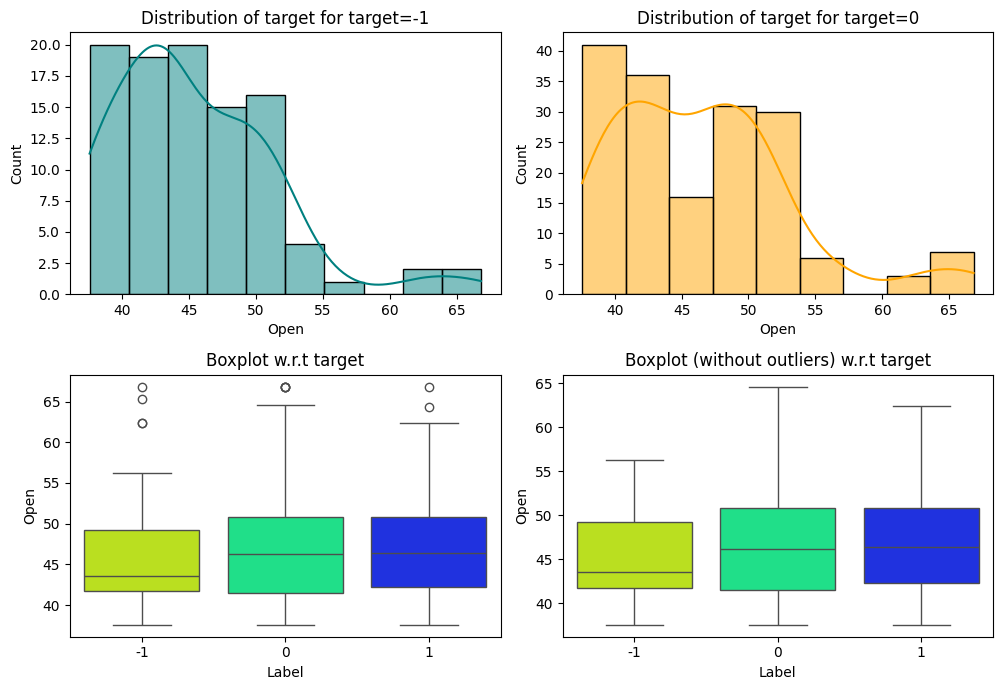

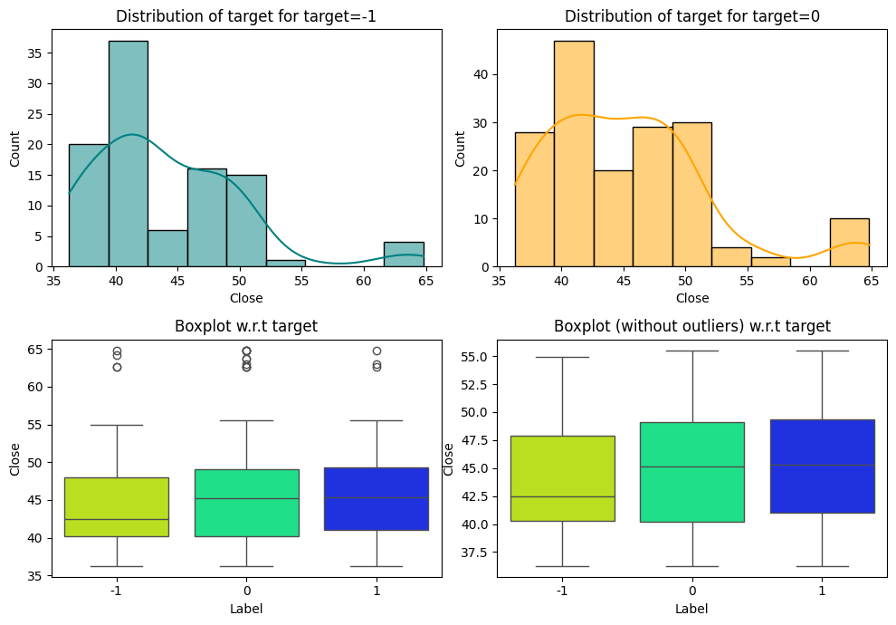

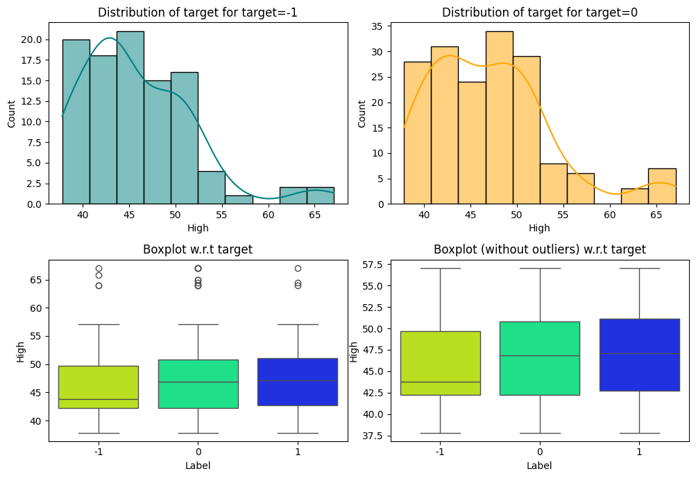

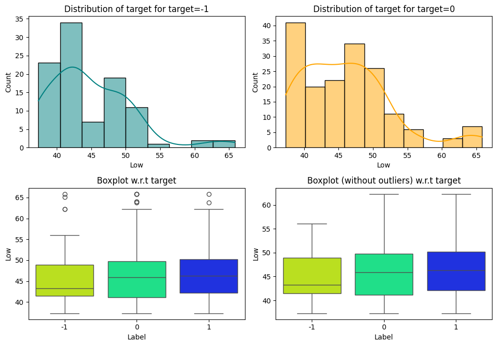

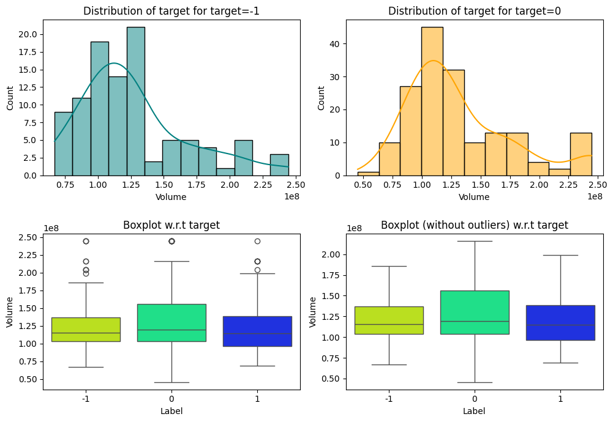

```python
for col in numerical_columns:
  distribution_plot_wrt_target(df, col, 'Label')
```

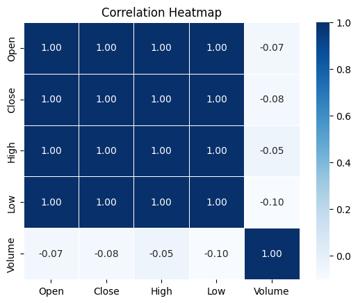

```python
sns.heatmap(df[numerical_columns].corr(), annot=True, fmt='.2f', cmap='Blues', linewidths=0.5)
plt.title('Correlation Heatmap')
plt.show()
```

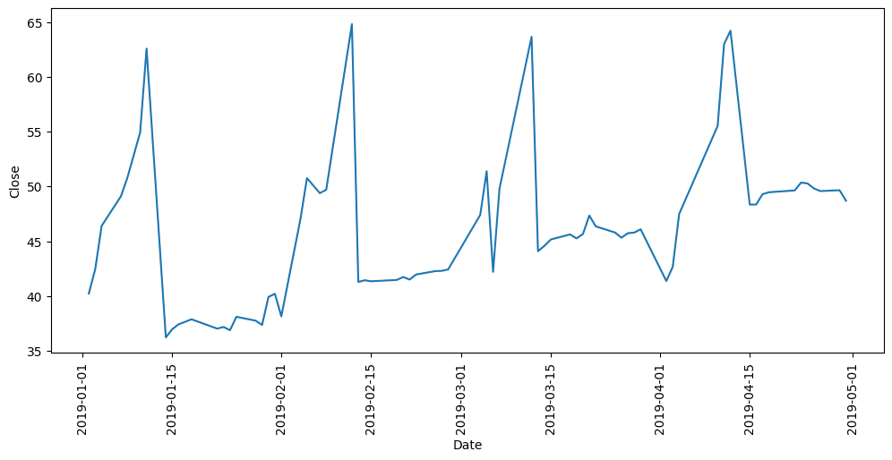

```python
#Timeseries plot for date vs label
plt.figure(figsize=(12, 5))
sns.lineplot(x="Date", y="Close", data=df)
plt.xticks(rotation=90)
plt.show()
```

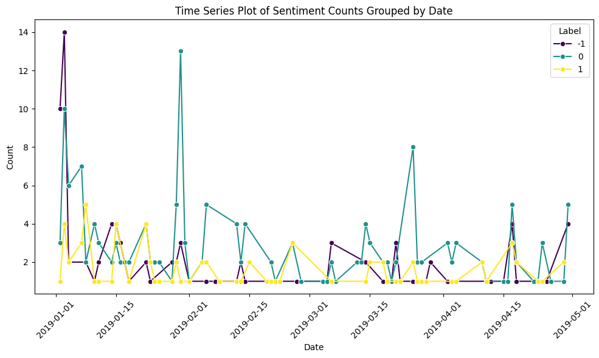

```python
#Timeseries plot for date vs label
timeseries_df = df.groupby(['Date', 'Label'])['Volume'].count().reset_index(name='Count')
plt.figure(figsize=(10, 6))
sns.lineplot(data=timeseries_df, x='Date', y='Count', hue='Label', marker='o', palette='viridis')
plt.title("Time Series Plot of Sentiment Counts Grouped by Date")
plt.xlabel("Date")
plt.ylabel("Count")
plt.xticks(rotation=45)
plt.legend(title="Label")
plt.tight_layout()
plt.show()
```

```python
#Compute and check the distribution of the length of news content
df['news_length'] = df['News'].apply(lambda x: len(x.split()))
```

```python
df.head()
```

|  | Date | News | Open | High | Low | Close | Volume | Label | news_length |
| --- | --- | --- | --- | --- | --- | --- | --- | --- | --- |
| 0 | 2019-01-02 | The tech sector experienced a significant decline in the aftermarket following Apple's Q1 revenue warning. Notable suppliers, including Skyworks, Broadcom, Lumentum, Qorvo, and TSMC, saw their stocks … | 41.740002 | 42.244999 | 41.482498 | 40.246914 | 130672400 | -1 | 45 |
| 1 | 2019-01-02 | Apple lowered its fiscal Q1 revenue guidance to $84 billion from earlier estimates of $89-$93 billion due to weaker than expected iPhone sales. The announcement caused a significant drop in Apple's st… | 41.740002 | 42.244999 | 41.482498 | 40.246914 | 130672400 | -1 | 50 |
| 2 | 2019-01-02 | Apple cut its fiscal first quarter revenue forecast from $89-$93 billion to $84 billion due to weaker demand in China and fewer iPhone upgrades. CEO Tim Cook also mentioned constrained sales of Airpod… | 41.740002 | 42.244999 | 41.482498 | 40.246914 | 130672400 | -1 | 48 |
| 3 | 2019-01-02 | This news article reports that yields on long-dated U.S. Treasury securities hit their lowest levels in nearly a year on January 2, 2019, due to concerns about the health of the global economy followi… | 41.740002 | 42.244999 | 41.482498 | 40.246914 | 130672400 | -1 | 50 |
| 4 | 2019-01-02 | Apple's revenue warning led to a decline in USD JPY pair and a gain in Japanese yen, as investors sought safety in the highly liquid currency. Apple's underperformance in Q1, with forecasted revenue o… | 41.740002 | 42.244999 | 41.482498 | 40.246914 | 130672400 | -1 | 49 |

```python
df['news_length'].describe()
```

```
count    349.000000
mean      48.349570
std        5.717324
min       18.000000
25%       45.000000
50%       49.000000
75%       52.000000
max       60.000000
Name: news_length, dtype: float64
```

## **Data Preprocessing**

### Removing HTML tags

```python
#Remove HTML tags if any in the news column of the dataframe
import re

def remove_html_tags(text):
    clean = re.compile('<.*?>')
    return re.sub(clean, '', text)
```

```python
df['News'] = df['News'].apply(lambda x: remove_html_tags(x))
```

```python
df['News'].sample(5)
```

```
89                                 The Dow Jones Industrial Average and S&P 500 ended lower on Monday as concerns over global growth weighed on tech stocks, while Citigroup's mixed fourth-quarter earnings report partially offset losses. The financial sector gained on Citigroup's strong earnings, but…
257                                                  Zeux, an FCA-regulated payments app, announced support for IOTA's MIOTA tokens. Users can now use these tokens to make payments at merchants accepting Apple Pay and Samsung Pay. The partnership between Zeux and the IOTA Foundation aims to increase…
250                                                                   Finnish game developer Rovio, known for Angry Birds, has released a new augmented reality (AR) game called Angry Birds Isle of Pigs. Developed in collaboration with Swedish studio Resolution Games, the game utilizes Apple's ARKit …
70      The Chinese authorities are expected to release a statement following the conclusion of U. S. trade talks in Beijing, with both sides signaling progress toward resolving the conflict that has roiled markets. Chinese Vice Premier Liu He, who is also the chief economic adviser to Chinese Presi…
121                        The White House reportedly rejected a scheduled meeting with Chinese officials this week due to disagreements over intellectual property rules, causing cautious trading in Asian stocks. China's Shanghai Composite and Shenzhen Component saw minimal changes, while the Hang S…
Name: News, dtype: object
```

### Lowercasing

```python
# changing the case of the text data to lower case
df['News'] = df['News'].str.lower()
```

### Removing extra whitespace

```python
# removing extra whitespaces from the text
df['News'] = df['News'].str.strip()
```

### Removing stopwords

```python
# defining a function to remove stop words using the NLTK library
def remove_stopwords(text):
    # Split text into separate words
    words = text.split()

    # Removing English language stopwords
    new_text = ' '.join([word for word in words if word not in stopwords.words('english')])

    return new_text
```

```python
# Applying the function to remove stop words using the NLTK library
df['News_without_stopwords'] = df['News'].apply(remove_stopwords)
```

### Stemming

Stemming is a language processing method that chops off word endings to find the root or base form of words.

For example,

- Original Word: Jumping, Stemmed Word: Jump
- Original Word: Running, Stemmed Word: Run

```python
# Loading the Porter Stemmer
ps = PorterStemmer()
```

```python
# defining a function to perform stemming
def apply_porter_stemmer(text):
    # Split text into separate words
    words = text.split()

    # Applying the Porter Stemmer on every word of a message and joining the stemmed words back into a single string
    new_text = ' '.join([ps.stem(word) for word in words])

    return new_text
```

```python
# Applying the function to perform stemming
df['News_cleaned_text'] = df['News_without_stopwords'].apply(apply_porter_stemmer)
```

```python
df.sample(5)
```

|  | Date | News | Open | High | Low | Close | Volume | Label | news_length | News_without_stopwords | News_cleaned_text |
| --- | --- | --- | --- | --- | --- | --- | --- | --- | --- | --- | --- |
| 207 | 2019-02-21 | goldman sachs is partnering with apple to launch co-branded credit cards, allowing users to manage finances via iphone and set spending goals. this deal benefits both companies; apple aims to boost it… | 42.950001 | 43.092499 | 42.575001 | 41.521526 | 68998800 | 1 | 50 | goldman sachs partnering apple launch co-branded credit cards, allowing users manage finances via iphone set spending goals. deal benefits companies; apple aims boost services business, goldman seeks … | goldman sach partner appl launch co-brand credit cards, allow user manag financ via iphon set spend goals. deal benefit companies; appl aim boost servic business, goldman seek increas consum loans. ca… |
| 59 | 2019-01-07 | stock index futures indicate a slightly lower open on wall street monday, as investors remain cautious amid lack of progress in u.s.-china trade talks and political risks from the ongoing government s… | 50.792500 | 51.122501 | 50.162498 | 49.110790 | 109012000 | 0 | 43 | stock index futures indicate slightly lower open wall street monday, investors remain cautious amid lack progress u.s.-china trade talks political risks ongoing government shutdown. dow futures flat, … | stock index futur indic slightli lower open wall street monday, investor remain cautiou amid lack progress u.s.-china trade talk polit risk ongo govern shutdown. dow futur flat, s&p 500 dip 0.13%, nas… |
| 317 | 2019-04-17 | on wednesday, morgan stanley's revenue fell less than expected, leading to a smaller profit decline. netflix added a record number of subscribers but missed consensus earnings forecasts for q2. qualco… | 49.884998 | 50.845001 | 49.652500 | 49.305897 | 115627200 | -1 | 52 | wednesday, morgan stanley's revenue fell less expected, leading smaller profit decline. netflix added record number subscribers missed consensus earnings forecasts q2. qualcomm saw surge stock price d… | wednesday, morgan stanley' revenu fell less expected, lead smaller profit decline. netflix ad record number subscrib miss consensu earn forecast q2. qualcomm saw surg stock price due patent settlement… |
| 151 | 2019-01-30 | the idc reported a decline in global smartphone shipments for q4, down 5% yoy to 375.4 million units, marking the fifth consecutive quarter of decreases. samsung (ks 005930) and apple (aapl) led with … | 40.812500 | 41.537498 | 40.057499 | 39.939968 | 244439200 | -1 | 37 | idc reported decline global smartphone shipments q4, 5% yoy 375.4 million units, marking fifth consecutive quarter decreases. samsung (ks 005930) apple (aapl) led market shares 18. | idc report declin global smartphon shipment q4, 5% yoy 375.4 million units, mark fifth consecut quarter decreases. samsung (k 005930) appl (aapl) led market share 18. |
| 37 | 2019-01-03 | this news article reports that on thursday, the two-year treasury note yield dropped below the federal reserve's effective rate for the first time since 2008. the market move suggests investors believ… | 43.570000 | 43.787498 | 43.222500 | 42.470604 | 103544800 | -1 | 54 | news article reports thursday, two-year treasury note yield dropped federal reserve's effective rate first time since 2008. market move suggests investors believe fed able continue tightening monetary… | news articl report thursday, two-year treasuri note yield drop feder reserve' effect rate first time sinc 2008. market move suggest investor believ fed abl continu tighten monetari policy. drop yield … |

## **Word Embeddings**

### Word Embeddings using Word2Vec

```python
words_list = [item.split(" ") for item in df['News'].values]
```

```python
# Creating an instance of Word2Vec
vec_size = 300
model_W2V = Word2Vec(words_list, vector_size = vec_size, min_count = 1, window=5, workers = 6)
```

```python
# Checking the size of the vocabulary
print("Length of the vocabulary is", len(list(model_W2V.wv.key_to_index)))
```

```
Length of the vocabulary is 4480
```

```python
# Checking the word embedding of a random word
word = "good"
model_W2V.wv[word]
```

```
array([ 0.00001941,  0.00088864,  0.00092892, -0.00061904, -0.00150854,
       -0.0035805 ,  0.00018933,  0.00046459,  0.00349813, -0.00312734,
        0.0002072 , -0.00083953, -0.00022011,  0.00146748,  0.00110084,
       -0.00335458,  0.00050644,  0.001216  , -0.00039584, -0.00123688,
       -0.00098907, -0.00108111,  0.00021516,  0.00041756,  0.00414884,
       -0.00008564, -0.00252396, -0.00129863, -0.00299144,  0.00071172,
       -0.00026766, -0.00260665, -0.00112453, -0.00265732, -0.00067193,
        0.00272406,  0.00152541, -0.00033794,  0.0001117 , -0.00251213,
       -0.00033317,  0.00191777, -0.00152848, -0.00200986, -0.0013931 ,
        0.00112043, -0.00190826, -0.00161902,  0.00123214,  0.00323056,
        0.00350324,  0.00213912, -0.00126829, -0.0027188 , -0.00252137,
        0.00323101, -0.00055591,  0.00264447,  0.00323737, -0.00185607,
        0.0011259 , -0.00073921,  0.00134185,  0.0000889 , -0.0025489 ,
       -0.00219234,  0.00242583,  0.00218034,  0.00078807, -0.00059257,
        0.00024316,  0.00395699, -0.00003038, -0.00430419, -0.00312774,
        0.00234045,  0.00183894,  0.00061039,  0.00220732,  0.00391426,
       -0.00300613, -0.0002462 ,  0.0010197 ,  0.00419717,  0.00148596,
       -0.00223449,  0.0031378 , -0.00124956,  0.00355335,  0.00138443,
        0.00126031, -0.00241198, -0.00272711, -0.00027328, -0.00017753,
        0.00355884,  0.00031583,  0.00231472,  0.00098568, -0.00239734,
        0.0028308 , -0.00017592,  0.00241028,  0.00101822, -0.00208359,
        0.00129737,  0.00274699,  0.00154962, -0.00279209,  0.0001382 ,
       -0.00337957,  0.00115846, -0.00268007, -0.00014359,  0.00214267,
        0.00205289,  0.00033804,  0.00008952,  0.00127541, -0.00003911,
       -0.00036214,  0.00307298,  0.00164739,  0.00018879,  0.00179179,
        0.00302781, -0.00116803, -0.00187617, -0.00266152,  0.0027063 ,
        0.00033847,  0.00331819, -0.00186749, -0.0007857 ,  0.00409355,
        0.00233619,  0.00078795,  0.00132686, -0.00354946, -0.00131255,
       -0.00248576, -0.00336285,  0.00246329,  0.00304776,  0.00305639,
       -0.00260763, -0.00135524, -0.00193613, -0.00245336, -0.00393433,
       -0.00200133, -0.00455436, -0.00058093, -0.00308958,  0.00230109,
        0.00357632,  0.00063944, -0.00050837, -0.0002745 ,  0.00370522,
       -0.00041838,  0.00097923,  0.00176593,  0.00247494, -0.002431  ,
        0.001297  ,  0.00030186,  0.00219685,  0.00194111,  0.00240943,
       -0.00202867, -0.00295294,  0.00136881, -0.00271878,  0.00055881,
        0.00248778, -0.00107037, -0.00129771,  0.00027466,  0.00175963,
       -0.0028988 ,  0.00197134, -0.00330406,  0.00259181, -0.00292452,
        0.00308023, -0.00168467, -0.00008566,  0.00227594, -0.00446569,
        0.00184646, -0.00251624,  0.00171958, -0.00212045, -0.00093348,
        0.00028444, -0.00288073, -0.00256017, -0.00264156, -0.002605  ,
        0.00264985,  0.0018368 , -0.00048439, -0.00090638, -0.00245378,
       -0.00239223,  0.000366  ,  0.00075044, -0.00110563, -0.00312062,
       -0.00202063, -0.00329655,  0.00083319, -0.00133213, -0.00192514,
        0.00103523, -0.00322375,  0.00069452,  0.00180343, -0.0031427 ,
       -0.00061638,  0.00244994, -0.0030235 ,  0.00209401,  0.00142102,
        0.00018177, -0.00000106,  0.001043  ,  0.00187943,  0.00241292,
        0.00335238, -0.0014306 , -0.00208766,  0.00312645, -0.0026495 ,
       -0.00243181, -0.00190831, -0.00133527, -0.00048628,  0.00152967,
        0.00277658,  0.0000116 , -0.00277143,  0.00085389,  0.00339512,
       -0.00062957,  0.00263561,  0.00208449, -0.00277074, -0.00206993,
       -0.00273054,  0.00283683, -0.0002926 , -0.00145667,  0.00060735,
       -0.00348474, -0.00122909,  0.00070532, -0.00054134, -0.00255251,
        0.00208811, -0.00089553,  0.00179336,  0.0016185 ,  0.00172758,
        0.003393  ,  0.00400748, -0.00107617, -0.00376888,  0.00341263,
       -0.00218189,  0.00337285,  0.00235048,  0.00195478,  0.00185121,
        0.0014141 , -0.00065109, -0.0020362 ,  0.00149185, -0.00157088,
       -0.00052788, -0.0016809 , -0.00113342,  0.0035045 , -0.00340296,
        0.00023792, -0.0006932 ,  0.00059097, -0.0007488 ,  0.0042963 ,
       -0.00049062, -0.00063663,  0.00284065,  0.00240414,  0.00188442,
        0.00148147,  0.00119783,  0.00095118,  0.00011926, -0.00178426],
      dtype=float32)
```

```python
# Checking top 5 similar words to the word 'best'
similar = model_W2V.wv.similar_by_word('good', topn=5)
print(similar)
```

```
[('tim', 0.42637744545936584), ('long-term', 0.41791224479675293), ('slow', 0.41339755058288574), ('available', 0.41304150223731995), ('music', 0.40614551305770874)]
```

```python
# Retrieving the words present in the Word2Vec model's vocabulary
words = list(model_W2V.wv.key_to_index.keys())

# Retrieving word vectors for all the words present in the model's vocabulary
wvs = model_W2V.wv[words].tolist()

# Creating a dictionary of words and their corresponding vectors
word_vector_dict = dict(zip(words, wvs))
```

```python
for key, value in word_vector_dict.items():
  print(key, value)
  break
```

[output not shown]

```python
def average_vectorizer_Word2Vec(doc):
    # Initializing a feature vector for the sentence
    feature_vector = np.zeros((vec_size,), dtype="float64")

    # Creating a list of words in the sentence that are present in the model vocabulary
    words_in_vocab = [word for word in doc.split() if word in words]

    # adding the vector representations of the words
    for word in words_in_vocab:
        feature_vector += np.array(word_vector_dict[word])

    # Dividing by the number of words to get the average vector
    if len(words_in_vocab) != 0:
        feature_vector /= len(words_in_vocab)

    return feature_vector
```

```python
# creating a dataframe of the vectorized documents
df_Word2Vec = pd.DataFrame(df['News'].apply(average_vectorizer_Word2Vec).tolist(), columns=['Feature '+str(i) for i in range(vec_size)])
df_Word2Vec
```

|  | Feature 0 | Feature 1 | Feature 2 | Feature 3 | Feature 4 | Feature 5 | Feature 6 | Feature 7 | Feature 8 | Feature 9 | ... | Feature 290 | Feature 291 | Feature 292 | Feature 293 | Feature 294 | Feature 295 | Feature 296 | Feature 297 | Feature 298 | Feature 299 |
| --- | --- | --- | --- | --- | --- | --- | --- | --- | --- | --- | --- | --- | --- | --- | --- | --- | --- | --- | --- | --- | --- |
| 0 | 0.002015 | 0.049605 | 0.026237 | 0.024655 | -0.012177 | -0.049692 | 0.026363 | 0.107309 | 0.011710 | -0.019555 | ... | 0.012354 | 0.047075 | 0.049627 | 0.007743 | 0.046657 | 0.057747 | 0.010673 | -0.017195 | 0.042032 | -0.011330 |
| 1 | 0.001942 | 0.045881 | 0.024189 | 0.023119 | -0.010948 | -0.045935 | 0.024646 | 0.098521 | 0.011320 | -0.018063 | ... | 0.011117 | 0.043497 | 0.045781 | 0.006912 | 0.043100 | 0.054248 | 0.009349 | -0.015827 | 0.039150 | -0.010721 |
| 2 | 0.001842 | 0.042308 | 0.022007 | 0.020757 | -0.009799 | -0.042221 | 0.022718 | 0.090377 | 0.010096 | -0.016589 | ... | 0.010425 | 0.040239 | 0.041880 | 0.006636 | 0.039433 | 0.049730 | 0.009251 | -0.014505 | 0.036023 | -0.010042 |
| 3 | 0.002219 | 0.049890 | 0.025634 | 0.024328 | -0.012221 | -0.048644 | 0.026276 | 0.105650 | 0.011638 | -0.019278 | ... | 0.011820 | 0.046089 | 0.048997 | 0.007722 | 0.045164 | 0.057319 | 0.010358 | -0.016657 | 0.041997 | -0.011013 |
| 4 | 0.001727 | 0.046272 | 0.024639 | 0.023001 | -0.011309 | -0.045690 | 0.024846 | 0.099682 | 0.011217 | -0.018525 | ... | 0.012036 | 0.043401 | 0.045932 | 0.007225 | 0.043229 | 0.053882 | 0.009564 | -0.015771 | 0.039420 | -0.010393 |
| ... | ... | ... | ... | ... | ... | ... | ... | ... | ... | ... | ... | ... | ... | ... | ... | ... | ... | ... | ... | ... | ... |
| 344 | 0.001722 | 0.032080 | 0.016490 | 0.015105 | -0.007597 | -0.031586 | 0.016611 | 0.068985 | 0.007434 | -0.012671 | ... | 0.007683 | 0.030089 | 0.031447 | 0.004817 | 0.030393 | 0.037542 | 0.006892 | -0.011411 | 0.026715 | -0.007091 |
| 345 | 0.000877 | 0.029900 | 0.015645 | 0.015151 | -0.007259 | -0.029632 | 0.016088 | 0.064575 | 0.007566 | -0.012467 | ... | 0.007496 | 0.027940 | 0.028965 | 0.004435 | 0.027018 | 0.035243 | 0.006055 | -0.010428 | 0.025069 | -0.006862 |
| 346 | 0.001611 | 0.039166 | 0.020159 | 0.019298 | -0.009867 | -0.038690 | 0.020289 | 0.082760 | 0.008936 | -0.015511 | ... | 0.009157 | 0.036781 | 0.038235 | 0.005539 | 0.036110 | 0.045442 | 0.008163 | -0.013349 | 0.032709 | -0.008818 |
| 347 | 0.001458 | 0.043504 | 0.022733 | 0.021765 | -0.010517 | -0.043229 | 0.023112 | 0.093323 | 0.010270 | -0.016900 | ... | 0.010738 | 0.041115 | 0.043009 | 0.006481 | 0.040557 | 0.050896 | 0.008963 | -0.015194 | 0.036820 | -0.010253 |
| 348 | 0.001529 | 0.049574 | 0.025977 | 0.024418 | -0.012206 | -0.049025 | 0.025872 | 0.106485 | 0.011961 | -0.019520 | ... | 0.012735 | 0.046443 | 0.049555 | 0.007435 | 0.046312 | 0.057656 | 0.010353 | -0.017345 | 0.042407 | -0.010772 |

349 rows × 300 columns

### Word Embeddings using Glove

```python
from gensim.models import KeyedVectors
# load the Stanford GloVe model
filename = r"C:\entryplus\ep-projects\NLP-SentimentAnalysis\glove.6B.100d.txt.word2vec"
glove_model = KeyedVectors.load_word2vec_format(filename, binary=False)
```

```python
# Checking the size of the vocabulary
print("Length of the vocabulary is", len(glove_model.index_to_key))
```

```
Length of the vocabulary is 400000
```

```python
# Checking the word embedding of a random word
word = "good"
glove_model[word]
```

```
array([-0.030769 ,  0.11993  ,  0.53909  , -0.43696  , -0.73937  ,
       -0.15345  ,  0.081126 , -0.38559  , -0.68797  , -0.41632  ,
       -0.13183  , -0.24922  ,  0.441    ,  0.085919 ,  0.20871  ,
       -0.063582 ,  0.062228 , -0.051234 , -0.13398  ,  1.1418   ,
        0.036526 ,  0.49029  , -0.24567  , -0.412    ,  0.12349  ,
        0.41336  , -0.48397  , -0.54243  , -0.27787  , -0.26015  ,
       -0.38485  ,  0.78656  ,  0.1023   , -0.20712  ,  0.40751  ,
        0.32026  , -0.51052  ,  0.48362  , -0.0099498, -0.38685  ,
        0.034975 , -0.167    ,  0.4237   , -0.54164  , -0.30323  ,
       -0.36983  ,  0.082836 , -0.52538  , -0.064531 , -1.398    ,
       -0.14873  , -0.35327  , -0.1118   ,  1.0912   ,  0.095864 ,
       -2.8129   ,  0.45238  ,  0.46213  ,  1.6012   , -0.20837  ,
       -0.27377  ,  0.71197  , -1.0754   , -0.046974 ,  0.67479  ,
       -0.065839 ,  0.75824  ,  0.39405  ,  0.15507  , -0.64719  ,
        0.32796  , -0.031748 ,  0.52899  , -0.43886  ,  0.67405  ,
        0.42136  , -0.11981  , -0.21777  , -0.29756  , -0.1351   ,
        0.59898  ,  0.46529  , -0.58258  , -0.02323  , -1.5442   ,
        0.01901  , -0.015877 ,  0.024499 , -0.58017  , -0.67659  ,
       -0.040379 , -0.44043  ,  0.083292 ,  0.20035  , -0.75499  ,
        0.16918  , -0.26573  , -0.52878  ,  0.17584  ,  1.065    ],
      dtype=float32)
```

```python
result = glove_model.most_similar("good", topn=5)
print(result)
```

```
[('better', 0.893191397190094), ('sure', 0.8314563035964966), ('really', 0.8297761678695679), ('kind', 0.8288268446922302), ('very', 0.8260800838470459)]
```

```python
glove_words = glove_model.index_to_key
```

```python
glove_word_vector_dict = dict(zip(glove_model.index_to_key,list(glove_model.vectors)))
```

```python
vec_size=100
```

```python
def average_vectorizer_GloVe(doc):
    # Initializing a feature vector for the sentence
    feature_vector = np.zeros((vec_size,), dtype="float64")

    # Creating a list of words in the sentence that are present in the model vocabulary
    words_in_vocab = [word for word in doc.split() if word in glove_words]

    # adding the vector representations of the words
    for word in words_in_vocab:
        feature_vector += np.array(glove_word_vector_dict[word])

    # Dividing by the number of words to get the average vector
    if len(words_in_vocab) != 0:
        feature_vector /= len(words_in_vocab)

    return feature_vector
```

```python
# creating a dataframe of the vectorized documents
df_Glove = pd.DataFrame(df['News'].apply(average_vectorizer_GloVe).tolist(), columns=['Feature '+str(i) for i in range(vec_size)])
df_Glove
```

|  | Feature 0 | Feature 1 | Feature 2 | Feature 3 | Feature 4 | Feature 5 | Feature 6 | Feature 7 | Feature 8 | Feature 9 | ... | Feature 90 | Feature 91 | Feature 92 | Feature 93 | Feature 94 | Feature 95 | Feature 96 | Feature 97 | Feature 98 | Feature 99 |
| --- | --- | --- | --- | --- | --- | --- | --- | --- | --- | --- | --- | --- | --- | --- | --- | --- | --- | --- | --- | --- | --- |
| 0 | -0.014904 | 0.062378 | 0.211063 | -0.059467 | 0.118378 | -0.275791 | -0.236422 | 0.072181 | -0.252987 | 0.076257 | ... | 0.069220 | 0.053232 | -0.355798 | 0.101399 | -0.506941 | 0.024346 | -0.103347 | -0.173299 | 0.668138 | -0.045392 |
| 1 | 0.035891 | 0.208518 | 0.274789 | -0.007572 | 0.108916 | -0.417096 | -0.218939 | -0.055825 | -0.187046 | 0.058298 | ... | 0.048908 | 0.196085 | -0.337476 | -0.165903 | -0.477262 | 0.117154 | 0.016394 | -0.198849 | 0.671375 | -0.039927 |
| 2 | 0.042664 | 0.136049 | 0.382726 | -0.094238 | 0.205402 | -0.400597 | -0.185915 | -0.006304 | -0.154110 | -0.005545 | ... | 0.144827 | 0.154903 | -0.154617 | -0.194681 | -0.595573 | 0.118003 | -0.030811 | -0.165687 | 0.677206 | -0.100077 |
| 3 | -0.042009 | 0.088889 | 0.456562 | -0.046780 | 0.104384 | -0.255045 | -0.282231 | -0.010215 | -0.196589 | -0.022995 | ... | 0.080078 | 0.085973 | -0.360293 | 0.131012 | -0.522607 | 0.094210 | -0.091016 | -0.310618 | 0.596537 | 0.037258 |
| 4 | -0.003463 | 0.111713 | 0.295273 | -0.000526 | 0.083260 | -0.158061 | -0.208042 | -0.132206 | -0.252122 | 0.135977 | ... | 0.101008 | 0.018789 | -0.253429 | -0.099667 | -0.351155 | 0.137302 | -0.036053 | -0.170933 | 0.454673 | -0.027627 |
| ... | ... | ... | ... | ... | ... | ... | ... | ... | ... | ... | ... | ... | ... | ... | ... | ... | ... | ... | ... | ... | ... |
| 344 | -0.081700 | 0.063302 | 0.316195 | -0.212603 | 0.112135 | 0.199832 | -0.152282 | 0.176874 | -0.098464 | 0.072450 | ... | 0.078499 | -0.143108 | -0.044067 | 0.100073 | -0.470918 | 0.006354 | -0.175671 | -0.258321 | 0.573625 | 0.276694 |
| 345 | 0.240577 | 0.186971 | 0.210854 | 0.093447 | 0.087266 | -0.388154 | -0.249757 | -0.107298 | -0.182972 | -0.128346 | ... | 0.011897 | 0.122765 | -0.171442 | 0.091952 | -0.561750 | 0.376794 | 0.122595 | -0.082494 | 0.555766 | 0.128828 |
| 346 | 0.093593 | 0.023056 | 0.321351 | -0.068911 | 0.076654 | -0.146345 | -0.108488 | 0.116766 | -0.384230 | -0.050718 | ... | -0.067547 | 0.170693 | -0.272347 | 0.030971 | -0.444742 | 0.028891 | -0.135362 | -0.174010 | 0.496407 | 0.143170 |
| 347 | -0.106427 | 0.050749 | 0.314678 | -0.057150 | 0.084253 | -0.286683 | -0.273979 | 0.051438 | -0.292650 | -0.084264 | ... | 0.005156 | -0.031723 | -0.252319 | -0.060274 | -0.541161 | 0.041857 | 0.081287 | -0.299750 | 0.638228 | 0.084232 |
| 348 | -0.020882 | 0.152162 | 0.302324 | -0.039027 | 0.105452 | -0.229216 | -0.048490 | 0.061053 | -0.227436 | 0.017500 | ... | 0.062042 | 0.147441 | -0.205973 | 0.278464 | -0.534245 | 0.045249 | -0.036089 | -0.277336 | 0.774677 | -0.105908 |

349 rows × 100 columns

### Semantic Search using Word2Vec

We want to search our database. We will compare a query's average word embedding to the average embedding of all the entries in the database. The entry in the database with the most similar average embedding will be returned.

```python
def average_vectorizer_Word2Vec2(doc, vec_size=300):
    # Initializing a feature vector for the sentence
    feature_vector = np.zeros((vec_size,), dtype="float64")

    # Creating a list of words in the sentence that are present in the model vocabulary
    words_in_vocab = [word for word in doc.split() if word in words]

    # adding the vector representations of the words
    for word in words_in_vocab:
        feature_vector += np.array(word_vector_dict[word])

    # Dividing by the number of words to get the average vector
    if len(words_in_vocab) != 0:
        feature_vector /= len(words_in_vocab)

    return feature_vector
```

```python
def embed_query(text, vec_size = 300):
  # we need to format the query the same way we formatted all the entries in the database!
  # We'll just use GloVe here, since it's the most recent model
  text = remove_html_tags(text)
  text = text.lower()
  text = text.strip()
  #text = remove_stopwords(text)
  #text = apply_porter_stemmer(text)
  avg_embed_query = average_vectorizer_Word2Vec2(text, vec_size = 300)
  return avg_embed_query
```

```python
value = embed_query("Apple's financial revenue.", vec_size = 300)
value
```

```
array([ 0.00052984,  0.02408263,  0.01163317,  0.01147759, -0.00594506,
       -0.02354239,  0.01408019,  0.04974088,  0.00441735, -0.00751416,
        0.00544435, -0.01889844,  0.00299027,  0.00106092, -0.02113095,
       -0.01548558,  0.01586812, -0.00656559,  0.00462552, -0.01681712,
       -0.01338502, -0.00430888,  0.01222195,  0.00648614,  0.01775784,
        0.0047579 , -0.03165779,  0.00838252, -0.01177857, -0.01830911,
        0.0076397 , -0.00582483,  0.00561137, -0.00087888, -0.00511896,
        0.00232053,  0.00730618, -0.02928949, -0.00489803, -0.00982221,
       -0.00475226,  0.00120173,  0.00429245, -0.02094165,  0.00556871,
        0.0193516 ,  0.00064012,  0.01017072, -0.0113712 ,  0.02152066,
        0.00557076,  0.0045055 , -0.01948497,  0.0083715 , -0.0020984 ,
        0.0133622 ,  0.00605282,  0.00513552,  0.00239073, -0.00329469,
       -0.00994951, -0.01059283, -0.00064186,  0.00999448, -0.00141392,
        0.00805994, -0.00103133,  0.00675667, -0.01503268, -0.00901056,
        0.00462734,  0.02074992,  0.01965271, -0.02014863,  0.00219397,
        0.00936663, -0.014591  ,  0.00467327, -0.0083164 ,  0.01414077,
       -0.00735448, -0.01392117,  0.00393017,  0.04754885,  0.00475122,
        0.00161223,  0.00067732,  0.00038505,  0.02035682,  0.0159236 ,
        0.02459575, -0.00859486,  0.00983409,  0.00495774,  0.01810341,
        0.01819749,  0.01733845, -0.00688703, -0.01555617,  0.01422929,
       -0.00145499, -0.00000524,  0.01692015,  0.00883277,  0.00702045,
       -0.01775357, -0.00586192,  0.00289697, -0.02786217, -0.00786064,
       -0.0311344 , -0.0207755 , -0.00083636,  0.01862188,  0.0185194 ,
        0.016938  , -0.00312798,  0.00213   ,  0.02374483, -0.02587565,
        0.0136677 ,  0.01692666,  0.01551194, -0.00301154, -0.00358164,
        0.02354569, -0.00763825, -0.01815791, -0.00067596,  0.02209069,
        0.01378256,  0.02540707,  0.00901086, -0.02791578,  0.01756233,
        0.01630968, -0.00430419, -0.0100566 , -0.02467709, -0.02025854,
        0.0158881 , -0.01732385, -0.00598521,  0.01147457,  0.00850187,
       -0.00804226, -0.02666951, -0.01348118,  0.01448811, -0.01387492,
       -0.00094047, -0.03589879, -0.01958232, -0.00343375,  0.00577197,
        0.01736503, -0.02275445, -0.00841962, -0.00793607,  0.03029654,
        0.00555869,  0.01964769, -0.02376859,  0.03035964, -0.00894763,
        0.01151656, -0.00415379, -0.00455227,  0.00171964,  0.04023781,
       -0.00673671,  0.00065746,  0.00910152,  0.01145778, -0.00631264,
        0.0029337 , -0.00991612, -0.01360225,  0.00915405, -0.00556453,
       -0.0149389 ,  0.02108267, -0.01173628, -0.01192199, -0.01093574,
        0.00712093,  0.02776081,  0.03367412,  0.0145263 , -0.02654743,
        0.01137922, -0.00188595, -0.02886339,  0.00293522,  0.00183739,
       -0.02349466,  0.00579476, -0.02047043,  0.00995705,  0.00108333,
       -0.01067883,  0.01155042, -0.00572904, -0.00938374,  0.00556793,
       -0.0078279 ,  0.00015339,  0.00969228, -0.00058326, -0.00929436,
       -0.00386841, -0.01990089, -0.00757608, -0.00982439,  0.01813396,
       -0.01375412, -0.00406122, -0.04670169, -0.02037453, -0.02697248,
        0.01441967,  0.01225263, -0.00443909, -0.01868697, -0.01816599,
       -0.00956705,  0.00548753, -0.00285436, -0.01506978,  0.00691693,
        0.0156736 , -0.01716836, -0.01414705,  0.01457938, -0.01981191,
        0.00955048,  0.00599654,  0.00799767,  0.0053239 , -0.02997183,
        0.01296325, -0.01336766, -0.01414301,  0.00540948,  0.01056187,
       -0.02398182, -0.00023073, -0.00448712,  0.00249893,  0.01476172,
        0.00131372,  0.0097243 ,  0.01407415, -0.01051814, -0.03024155,
       -0.01708033,  0.03516068,  0.01055791, -0.03370532, -0.01557259,
        0.00587609,  0.01006401,  0.00598688, -0.02885208, -0.0268491 ,
        0.00877112,  0.01558701,  0.01909068, -0.02363668,  0.00927955,
       -0.01213168,  0.00541934,  0.00607427, -0.00801829,  0.02531366,
        0.00446984,  0.01841815,  0.00463799, -0.02687186,  0.00024305,
        0.0048317 , -0.005149  , -0.00201517,  0.00632298,  0.0006861 ,
        0.00121123, -0.02733558,  0.01315292, -0.00110854,  0.01935198,
        0.00713198,  0.02051778,  0.02383867,  0.00244539,  0.02274934,
        0.02912449,  0.00478861, -0.00988957,  0.02052339, -0.00516484])
```

```python
words_numpy = df_Word2Vec.to_numpy()
def search_database(query,top_k=5):
  query_embed = embed_query(query)
  query_norm = np.sqrt(np.sum(query_embed**2))
  cosine_sim = np.dot(words_numpy,query_embed)/query_norm
  for i in range(df_Word2Vec.shape[0]):
    cosine_sim[i] /= np.sqrt(np.sum(words_numpy[i,:]**2))
  best_index = np.argsort(cosine_sim)[::-1]
  best_index = best_index[:top_k]
  return best_index
```

```python
queries_for_categorization = [
    "Overall the company's performance, growth and revenue in the entire year.",
    "Earnings summary for the quarter.",
    "Quarterly results for the company",
    "Period company performed poorly.",
    "Quater that earned poor ratings for the company."
]
```

```python
for query in queries_for_categorization:
  print(query)
  best_ind = search_database(query,top_k=2)
  print(df['News'][best_ind])
```

```
Overall the company's performance, growth and revenue in the entire year.
0      the tech sector experienced a significant decline in the aftermarket following apple's q1 revenue warning. notable suppliers, including skyworks, broadcom, lumentum, qorvo, and tsmc, saw their stocks drop in response to apple's downward revision of its revenue expectations for the quarter, pr…
175            two u.s. house democrats, frank pallone and jan schakowsky, have expressed concern over apple's handling of a privacy flaw in its facetime group video chat software. the bug allowed users to hear audio before the call was answered, and the teen who discovered it tried for days to aler…
Name: News, dtype: object
Earnings summary for the quarter.
336    sony, the japanese technology giant, announced a sharper than expected drop in annual profit due to a slower gaming business with the playstation 4 console nearing the end of its life. the company warned of significant changes to the operating environment and withdrew earnings goals for indiv…
182                                                                                                           analysts predict a decline of 0.1% in first quarter earnings for s&p 500 companies, marking the group's first quarterly profit decrease since 2016 according to refinitiv data. the forecast r…
Name: News, dtype: object
Quarterly results for the company
186    apple is facing resistance from several publications over its proposed news subscription service, which could be priced around $10 per month. the company plans to keep about half of the revenue but has not yet finalized the price. apple's transaction fee of 30 percent for software developers …
320                                                            in the news article, taiwan semiconductor manufacturing company (tsmc), the world's largest contract chipmaker, reported a steep quarterly profit drop of 32% due to weak global demand for smartphones and the prolonged u.s.-china trade wa…
Name: News, dtype: object
Period company performed poorly.
258    tesla has filed a lawsuit against a former engineer, guangzhi cao, for allegedly copying autopilot source code before joining chinese startup xiaopeng motors technology company ltd. the company also accused four former employees and u.s. self-driving car startup zoox of stealing proprietary i…
48                           amazon has sold over 100 million devices with its alexa digital assistant, according to the verge. the company is cautious about releasing hardware sales figures and did not disclose holiday numbers for the echo dot. over 150 products feature alexa, and more than 28,000 …
Name: News, dtype: object
Quater that earned poor ratings for the company.
150    apple's q4 earnings report showed better-than-expected results, with some weakness already priced in due to the pre-announcement revenue cut. analysts at morgan stanley and jpmorgan remain overweight on the stock, with the latter noting that investor focus should return to the services opport…
196                          the eu general court dealt a potential setback to the european commission's campaign against corporate tax avoidance by annulling an order for belgian tax break schemes worth about 700 million euros to multinational firms, including fiat chrysler, amazon, engie, and appl…
Name: News, dtype: object
```

### Semantic Search using Glove

```python
def average_vectorizer_GloVe2(doc, vec_size=100):
    # Initializing a feature vector for the sentence
    feature_vector = np.zeros((vec_size,), dtype="float64")

    # Creating a list of words in the sentence that are present in the model vocabulary
    words_in_vocab = [word for word in doc.split() if word in glove_words]

    # adding the vector representations of the words
    for word in words_in_vocab:
        feature_vector += np.array(glove_word_vector_dict[word])

    # Dividing by the number of words to get the average vector
    if len(words_in_vocab) != 0:
        feature_vector /= len(words_in_vocab)

    return feature_vector
```

```python
def embed_query2(text):
  # we need to format the query the same way we formatted all the entries in the database!
  # We'll just use GloVe here, since it's the most recent model
  text = remove_html_tags(text)
  text = text.lower()
  text = text.strip()
  #text = remove_stopwords(text)
  #text = apply_porter_stemmer(text)
  avg_embed_query = average_vectorizer_GloVe2(text, 100)
  return avg_embed_query
```

```python
glove_numpy = df_Glove.to_numpy()
def search_database2(query,top_k=5):
  query_embed = embed_query2(query)
  query_norm = np.sqrt(np.sum(query_embed**2))
  cosine_sim = np.dot(glove_numpy,query_embed)/query_norm
  for i in range(df_Glove.shape[0]):
    cosine_sim[i] /= np.sqrt(np.sum(glove_numpy[i,:]**2))
  best_index = np.argsort(cosine_sim)[::-1]
  best_index = best_index[:top_k]
  return best_index
```

```python
queries_for_categorization = [
    "Overall the company's performance, growth and revenue in the entire year.",
    "Earnings summary for the quarter.",
    "Quarterly results for the company",
    "Period company performed poorly.",
    "Quater that earned poor ratings for the company."
]
```

```python
for query in queries_for_categorization:
  print(query)
  bestind = search_database2(query,top_k=2)
  print(df['News'][bestind])
```

```
Overall the company's performance, growth and revenue in the entire year.
8    apple's fiscal first quarter revenue came in below analysts' estimates at around $84 billion, a significant drop from the forecasted range of $89-$93 billion. the tech giant attributed the shortfall to lower iphone revenue and upgrades, as well as weakness in emerging markets. several brokerage…
0                        the tech sector experienced a significant decline in the aftermarket following apple's q1 revenue warning. notable suppliers, including skyworks, broadcom, lumentum, qorvo, and tsmc, saw their stocks drop in response to apple's downward revision of its revenue expectations f…
Name: News, dtype: object
Earnings summary for the quarter.
346    this article reports that the s&p 500 reached another record high close on tuesday, marking its best four-month stretch since late 2010. apple's strong quarterly results and positive earnings forecast helped ease concerns about the bull run's sustainability, despite a revenue miss from google…
182                                         analysts predict a decline of 0.1% in first quarter earnings for s&p 500 companies, marking the group's first quarterly profit decrease since 2016 according to refinitiv data. the forecast represents a significant drop from the start of the year when growt…
Name: News, dtype: object
Quarterly results for the company
209    kraft heinz suffered a significant loss in premarket trade due to a disappointing earnings report and an sec investigation. the company wrote down $15.4 billion from its kraft and oscar mayer trademarks, and is under scrutiny for accounting practices. roku stock surged following better-than-e…
346         this article reports that the s&p 500 reached another record high close on tuesday, marking its best four-month stretch since late 2010. apple's strong quarterly results and positive earnings forecast helped ease concerns about the bull run's sustainability, despite a revenue miss from g…
Name: News, dtype: object
Period company performed poorly.
162    peter jackson, the director of "lord of the rings," is making a movie about the beatles using previously unseen studio footage from their final album recording sessions in january 1969. this project marks the 50th anniversary since their last live performance together. jackson will utilize ov…
195             warren buffett's berkshire hathaway reduced its stake in apple, though none of the selling was done by buffett himself. the company added positions in suncor energy and software firm red hat, while also appearing to have sold off a significant stake in oracle. berkshire's u.s.-listed…
Name: News, dtype: object
Quater that earned poor ratings for the company.
346    this article reports that the s&p 500 reached another record high close on tuesday, marking its best four-month stretch since late 2010. apple's strong quarterly results and positive earnings forecast helped ease concerns about the bull run's sustainability, despite a revenue miss from google…
182                                         analysts predict a decline of 0.1% in first quarter earnings for s&p 500 companies, marking the group's first quarterly profit decrease since 2016 according to refinitiv data. the forecast represents a significant drop from the start of the year when growt…
Name: News, dtype: object
```

### Semantic Search using **Transformer** model

We'll be using the all-MiniLM-L6-v2 model here.

💡 The all-MiniLM-L6-v2 model is an all-round (all) model trained on a large and diverse dataset of over 1 billion training samples and generates state-of-the-art sentence embeddings of 384 dimensions.

📊 It is a language model (LM) that has 6 transformer encoder layers (L6) and is a smaller model (Mini) trained to mimic the performance of a larger model (BERT).

🛠️ Potential use-cases include text classification, sentiment analysis, and semantic search.

```python
# defining the model
model = SentenceTransformer('sentence-transformers/all-MiniLM-L6-v2')
```

```python
# encoding the dataset
embedding_matrix = model.encode(df['News'], show_progress_bar=True)
```

```python
# printing the shape of the embedding matrix
embedding_matrix.shape
```

```
(349, 384)
```

```python
embedding_matrix[0,:]
```

[output not shown]

#### **Querying from the dataset**

```python
# defining a function to find the top k similar sentences for a given query
def top_k_similar_sentences(embedding_matrix,query_text,k):
    # encoding the query text
    query_embedding = model.encode(query_text)

    # calculating the cosine similarity between the query vector and all other encoded vectors of our dataset
    score_vector = np.dot(embedding_matrix,query_embedding)

    # sorting the scores in descending order and choosing the first k
    top_k_indices = np.argsort(score_vector)[::-1][:k]

    # returning the corresponding reviews
    return df.loc[list(top_k_indices), 'News']
```

```python
# defining the query text
query_text = "Apple's financial revenue in the last quarter."

# displaying the top 5 similar sentences
top_k_reviews = top_k_similar_sentences(embedding_matrix,query_text,5)

for i in top_k_reviews:
    print(i, end="\n\n")
```

```
apple's fiscal first quarter revenue came in below analysts' estimates at around $84 billion, a significant drop from the forecasted range of $89-$93 billion. the tech giant attributed the shortfall to lower iphone revenue and upgrades, as well as weakness in emerging markets. several brokerages had…

apple reported stronger-than-expected earnings for q1 2023, with gaap eps coming in at $4.18 versus the estimated $4.17. revenue surpassed expectations as well, reaching $84.3 billion compared to forecasts of $81 billion, representing a year-over

in after hours trading, apple's shares rose despite a rare revenue decline due to weak iphone sales, particularly in china. the tech giant reported earnings of $4.18 per share, slightly better than expected, but overall revenue was down 4.5%. for the second quarter, apple anticipates revenue between…

apple cut its fiscal first quarter revenue forecast from $89-$93 billion to $84 billion due to weaker demand in china and fewer iphone upgrades. ceo tim cook also mentioned constrained sales of airpods and macbooks. apple's shares fell 8.5% in post market trading, while asian suppliers like hon

apple is expected to report lower-than-projected fiscal first quarter earnings, with revenue falling significantly due to disappointing iphone sales in china. this follows china's emergence as a major challenge for apple due to trade tensions and competition from lower-priced smartphones from compet…
```